# A data analysis case study of COVID-19 in Taiwan

**Author: Kuan-ju Huang**  
**Data up to 2020/06/01**

# 1. Introduction

On **March 11, 2020**, the World Health Organization (WHO) declared novel coronavirus (COVID-19) as a global pandemic. Until now, there are more than 7,000,000 infected cases and more than 430,000 deaths around the world. Although not being part of the WHO, Taiwan reported the first confirmed infected case on **January 21, 2020**, and started taking a series of precaution to prevent the virus from spreading out. Six months later (June 01, 2020),**Taiwan has 443 infected cases, 7 deaths and 431 recovery cases.** In this project, the data analysis of COVID-19 is based on a case study of Taiwan. There are three sections in the project,

1. A brief overview of the COVID-19 in Taiwan and its trend
2. Distribution of the COVID-19 confirmed cases based on different categories
3. The relations between total confirmed cases, deaths and recovery cases

## Data Preprocessing and Overview

```python
import matplotlib
import matplotlib.pyplot as plt
import matplotlib.dates as mdates
from matplotlib.dates import DateFormatter
import numpy as np
plt.style.use('default')
import datetime
import pandas as pd
import geopandas as gp
import seaborn as sns
pd.set_option('mode.chained_assignment', None)
```

The datasets are collected and downloaded from

1. 嚴重特殊傳染性肺炎 Taiwan CDC 公布病例資訊 Daily updated
2. [台灣衛生福利部疾病管制署(CDC)](https://data.cdc.gov.tw/dataset/aagstable-weekly-19cov) Weekly updated
3. [kaggle Novel Corona Virus 2019 Dataset](https://www.kaggle.com/sudalairajkumar/novel-corona-virus-2019-dataset/data#covid_19_data.csv) Daily updated

```python
Covid19_Taiwan = pd.read_table('嚴重特殊傳染性肺炎 Taiwan CDC 公布病例資訊 - 確診病例.csv',sep=",")
Covid19_Taiwan = Covid19_Taiwan.drop(['CDC 新聞稿 URL','就醫日','群組','確診前症狀','其他公布說明'
                                      ,'解除隔離日'],axis=1)

Covid19_cases_domestic = Covid19_Taiwan[ Covid19_Taiwan['境外或是本土']=='本土']
Covid19_cases_imported = Covid19_Taiwan[ Covid19_Taiwan['境外或是本土']=='境外']
Covid19_death = Covid19_Taiwan[- Covid19_Taiwan['死亡日'].isnull()]

End_date = '20200531'

date = pd.date_range('20200101', End_date)

Covid19_Taiwan_cases ={
    'Date': date.date,
    'Domestic': np.zeros(len(date.date)),
    'Imported': np.zeros(len(date.date)),
    'Death': np.zeros(len(date.date))
}
Covid19_Taiwan_cases= pd.DataFrame(Covid19_Taiwan_cases,dtype='int64')

Covid19_cases_domestic.loc[:,'確診日']=pd.to_datetime(Covid19_cases_domestic.loc[:,'確診日'])
Covid19_cases_imported.loc[:,'確診日']=pd.to_datetime(Covid19_cases_imported.loc[:,'確診日'])
Covid19_death.loc[:,'死亡日']=pd.to_datetime(Covid19_death.loc[:,'死亡日'])

def reconstruct(s1, s2, t1, t2):
    for i in range(t1.shape[0]):
        for j in range(t2.shape[0]):
            if t1.loc[i,'Date'] == t2.iloc[j][s1]:
                t1.loc[i,s2]+=1

    return t1



Covid19_Taiwan_cases = reconstruct('確診日', 'Domestic', Covid19_Taiwan_cases, Covid19_cases_domestic)
Covid19_Taiwan_cases = reconstruct('確診日', 'Imported', Covid19_Taiwan_cases, Covid19_cases_imported)
Covid19_Taiwan_cases = reconstruct('死亡日', 'Death', Covid19_Taiwan_cases, Covid19_death)
```

```python
print('First Dataset')
print(Covid19_Taiwan_cases)
print("----------分格線----------")
Covid19_Condition = pd.read_table('Weekly_Age_County_Gender_19CoV.csv',sep=",")
print('Second Dataset')
print(Covid19_Condition)
print("----------分格線----------")
Covid19_Taiwan_overall = pd.read_table('covid_19_data.csv',sep=",")
Covid19_Taiwan_overall=Covid19_Taiwan_overall[Covid19_Taiwan_overall['Country/Region'] =='Taiwan']
Covid19_Taiwan_overall_1=Covid19_Taiwan_overall[['ObservationDate','Confirmed','Deaths','Recovered']]
print('Third Dataset')
print(Covid19_Taiwan_overall_1)
```

```
First Dataset
           Date  Domestic  Imported  Death
0    2020-01-01         0         0      0
1    2020-01-02         0         0      0
2    2020-01-03         0         0      0
3    2020-01-04         0         0      0
4    2020-01-05         0         0      0
..          ...       ...       ...    ...
147  2020-05-27         0         0      0
148  2020-05-28         0         0      0
149  2020-05-29         0         1      0
150  2020-05-30         0         0      0
151  2020-05-31         0         0      0

[152 rows x 4 columns]
```

[output cut: 32 more lines]

## 2. Brief Overview of the Current Situation

In this section, the daily confirmed cases of COVID-19 and daily deaths in Taiwan are presented. Also, the total confirmed cases and total deaths are shown below in section 2.3. All the graphs below indicate the date on the x-axis.

### 2.1. COVID-19 Taiwan Daily Confirmed Cases by Infected Source

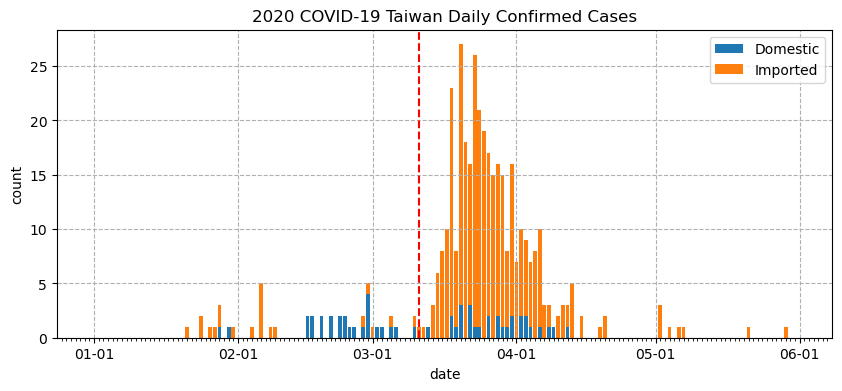

```python
Covid19_Taiwan_cases
Covid19_Taiwan_cases['Date'] = pd.to_datetime(Covid19_Taiwan_cases['Date'],format="%Y-%m-%d")
Covid19_Taiwan_cases

index = Covid19_Taiwan_cases[Covid19_Taiwan_cases.Date == '2020-03-11'].index.tolist()[0]# 找出2020-03-11的索引
# print(index)#˙70
fig, ax1 = plt.subplots(figsize=(10, 4))
plt.bar(date, Covid19_Taiwan_cases['Domestic'], label = 'Domestic')
plt.bar(date, Covid19_Taiwan_cases['Imported'], bottom = Covid19_Taiwan_cases['Domestic'],label = 'Imported')
plt.axvline (Covid19_Taiwan_cases.loc[70,'Date'],ymin = 0, ymax = 1, color = 'red', ls = '--')
date_form = DateFormatter("%m-%d")
ax1.xaxis.set_major_formatter(date_form)
ax1.xaxis.set_minor_locator(mdates.DayLocator(interval = 1))
plt.title('2020 COVID-19 Taiwan Daily Confirmed Cases')
plt.grid(linestyle='--')
plt.legend()
plt.xlabel('date')
plt.ylabel('count')
plt.show()
```

### 2.2. COVID-19 Taiwan Daily Deaths

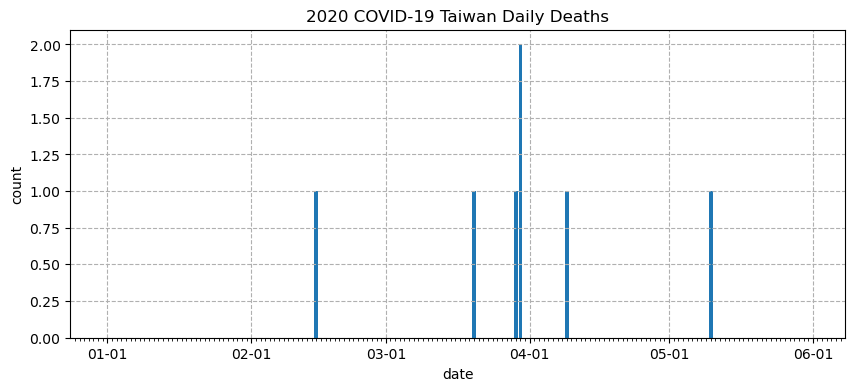

```python
fig, ax = plt.subplots(figsize=(10, 4))
plt.bar(date, Covid19_Taiwan_cases['Death'])
date_form = DateFormatter("%m-%d")
ax.xaxis.set_major_formatter(date_form)
ax.xaxis.set_minor_locator(mdates.DayLocator(interval = 1))
plt.title('2020 COVID-19 Taiwan Daily Deaths')
plt.grid(linestyle='--')
plt.xlabel('date')
plt.ylabel('count')
plt.show()
```

During the past four months, there are very few deaths reported from Taiwan and the maximum amount of single-day deaths is **2** cases on **March 30**.

```python
Covid19_Taiwan = pd.read_table('嚴重特殊傳染性肺炎 Taiwan CDC 公布病例資訊 - 確診病例.csv',sep=",")
Covid19_Taiwan_1=Covid19_Taiwan[['案例編號','性別','Age','確診日','相關地點','境外或是本土','其他公布說明','死亡日']]
Covid19_Taiwan_death= Covid19_Taiwan_1[-Covid19_Taiwan['死亡日'].isnull()]
Covid19_Taiwan_death
```

|  | 案例編號 | 性別 | Age | 確診日 | 相關地點 | 境外或是本土 | 其他公布說明 | 死亡日 |
| --- | --- | --- | --- | --- | --- | --- | --- | --- |
| 18 | 19 | 男 | 60.0 | 2020/2/16 | NaN | 本土 | 有B型肝炎及糖尿病病史，無出國旅遊史，亦非確診病例之已知密切接觸者。於1月27日出現咳嗽，2... | 2020/2/15 |
| 26 | 27 | 男 | 80.0 | 2020/2/23 | NaN | 本土 | 本身為具高血壓、糖尿病等慢性病之洗腎病人，近期無出國史。案27於2月6日出現咳嗽、流鼻水等症... | 2020/3/20 |
| 33 | 34 | 女 | 50.0 | 2020/2/28 | NaN | 本土 | 有糖尿病原、心血管疾病等慢性病史，2月14日因低血糖、全身倦怠情形就醫並收治住院，當時無呼吸... | 2020/3/30 |
| 100 | 101 | 男 | 70.0 | 2020/3/19 | 埃及 | 境外 | 3月3日至12日至埃及旅遊(與案55、63、71同團)，3月17日陸續出現發燒、流鼻水、肌肉... | 2020/4/9 |
| 107 | 108 | 男 | 40.0 | 2020/3/19 | 奧地利,捷克 | 境外 | 3月5日至3月14日跟團至奧地利、捷克旅遊(與案61、72同團)。於3月17日出現發燒症狀，... | 2020/3/29 |
| 169 | 170 | 男 | 60.0 | 2020/3/23 | 西班牙 | 境外 | 3月12日至20日至西班牙旅遊，3月20日出現發燒、咳嗽症狀，3月20日返國時經發燒篩檢站採... | 2020/3/30 |
| 196 | 197 | 男 | 40.0 | 2020/3/24 | 美國 | 境外 | 3月8日至18日至美國探親，於3月19日出現發燒症狀，3月21日就醫並採檢送驗，今日確診，為... | 2020/5/10 |

## 2.3. COVID-19 Taiwan Total Confirmed Cases and Deaths

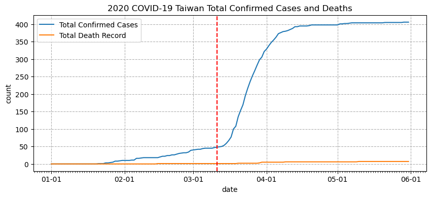

```python
Daily_confimed_cases = Covid19_Taiwan_cases['Domestic']+Covid19_Taiwan_cases['Imported']
Total_confimed_cases = Daily_confimed_cases.cumsum()
fig, ax = plt.subplots(figsize=(10, 4))
plt.plot(date, Total_confimed_cases, label = 'Total Confirmed Cases')
plt.plot(date, Covid19_Taiwan_cases['Death'].cumsum(), label = 'Total Death Record')
date_form = DateFormatter("%m-%d")
ax.xaxis.set_major_formatter(date_form)
ax.xaxis.set_minor_locator(mdates.DayLocator(interval = 1))
plt.axvline (Covid19_Taiwan_cases.loc[70,'Date'],ymin = 0, ymax = 1, color = 'red', ls = '--')
plt.legend()
plt.title('2020 COVID-19 Taiwan Total Confirmed Cases and Deaths')
plt.grid(linestyle='--')
plt.xlabel('date')
plt.ylabel('count')
plt.show()
```

Taiwan reported the first COVID-19 confirmed case on **January 21** and the first death on **February 15**. The red dash line in the above figure represents the time when WHO declared COVID-19 as a global pandemic. From the above trend, it shows that:

1. **Before March 11, the time when WHO declared COVID-19 as a global pandemic, the total amount of confirmed cases increased slowly and linearly from January 21.**
2. **The trend of the total confirmed cases had a rapid increase after March 15 and the total of confirmed cases jumped from 50 cases to near 400 cases in approximately one month.**
3. **On April 15, the increasing rate of total confirmed cases stared to get slower.**
4. The total of deaths increases to **7** cases until now.
5. The increasing rate of total confirmed cases is relatively faster than the total deaths.

## 3. Distribution of COVID-19 Confirmed Cases in Taiwan by Categories

In this section, the COVID-19 confirmed cases in Taiwan are divided by different categories, including age, gender, county and infected source to analyze the distribution.

### 3.1. Distribution by Age and Gender

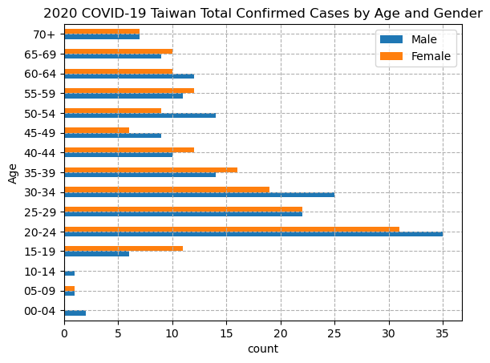

```python
Covid19_Age_Gender = Covid19_Condition[['性別','年齡層','確定病例數']]


Covid19_Age_m = Covid19_Age_Gender[Covid19_Age_Gender['性別']=='M']
for i, row in Covid19_Age_m.iterrows():
    if Covid19_Age_m.loc[i,'年齡層'] == '4':
        Covid19_Age_m.loc[i,'年齡層'] = '00-04'
    elif Covid19_Age_m.loc[i,'年齡層'] == '5-9':
        Covid19_Age_m.loc[i,'年齡層'] = '05-09'

Covid19_Age_m = Covid19_Age_m.groupby('年齡層', as_index=False)['確定病例數'].count()
# Covid19_Age_m

Covid19_Age_f = Covid19_Age_Gender[Covid19_Age_Gender['性別']=='F']
for i, row in Covid19_Age_f.iterrows():
    if Covid19_Age_f.loc[i,'年齡層'] == '4':
        Covid19_Age_f.loc[i,'年齡層'] = '00-04'
    elif Covid19_Age_f.loc[i,'年齡層'] == '5-9':
        Covid19_Age_f.loc[i,'年齡層'] = '05-09'
Covid19_Age_f = Covid19_Age_f.groupby('年齡層', as_index=False)['確定病例數'].count()
Covid19_Age_f = Covid19_Age_f.append([{'年齡層':'00-04','確定病例數':'0'}],ignore_index=True)
Covid19_Age_f = Covid19_Age_f.sort_values('年齡層')
# Covid19_Age_f

Covid19_age_gender_result = pd.merge(Covid19_Age_m, Covid19_Age_f, on='年齡層', how='left')
Covid19_age_gender_result.rename(columns={'年齡層':'Age','確定病例數_x': 'Male','確定病例數_y': 'Female'}, inplace=True)
Covid19_age_gender_result['Female']= Covid19_age_gender_result['Female'].apply(lambda x: 0 if pd.isnull(x) else x).astype(int)
Covid19_age_gender_result
Covid19_age_gender_result.plot('Age',kind='barh')

plt.title('2020 COVID-19 Taiwan Total Confirmed Cases by Age and Gender')
plt.grid(linestyle='--')
plt.xlabel('count')
plt.show()
```

### 3.2. Distribution by County

#### 3.2.1. Bar Graph

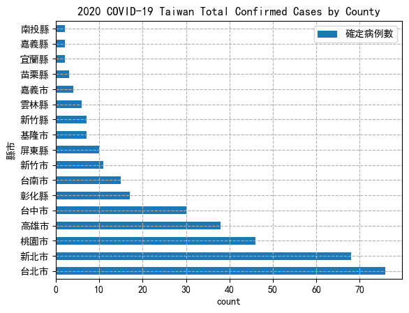

```python
plt.rcParams['font.sans-serif'] = ['simhei']
plt.rcParams['axes.unicode_minus'] = False
Covid19_county_case = Covid19_Condition[['縣市','確定病例數']]
Covid19_county_case = Covid19_county_case.groupby('縣市', as_index=False)['確定病例數'].count()
Covid19_county_case = Covid19_county_case.sort_values('確定病例數', ascending=False)
Covid19_county_case

Covid19_county_case.plot('縣市',kind='barh')
plt.title('2020 COVID-19 Taiwan Total Confirmed Cases by County')
plt.grid(linestyle='--')
plt.xlabel('count')
plt.show()
```

#### 3.2.2. Pie Chart

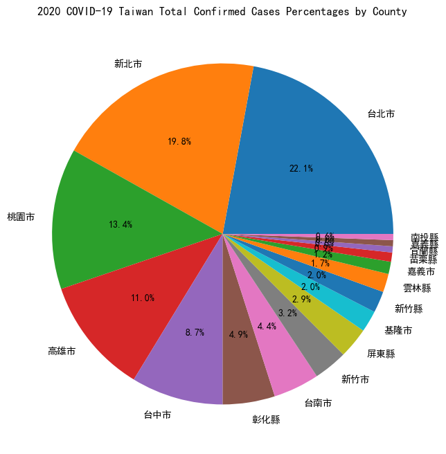

```python
fig, ax = plt.subplots(figsize=(8, 8))
plt.title('2020 COVID-19 Taiwan Total Confirmed Cases Percentages by County')
plt.pie(Covid19_county_case['確定病例數'],autopct = '%.1f%%', radius = 1, labels = Covid19_county_case['縣市'])
plt.show()
```

#### 3.2.3. Map

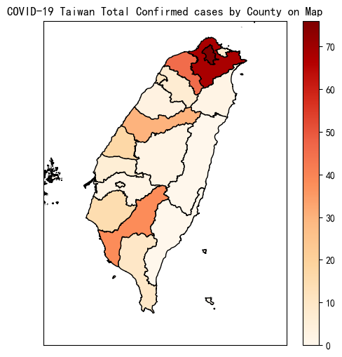

```python
county_shp = gp.read_file('COUNTY_MOI_1081121.shp', encoding='utf-8')
county_shp
county_shp.loc[8, 'COUNTYNAME'] = '台北市'
county_shp.loc[10, 'COUNTYNAME'] = '台中市'
county_shp.loc[11, 'COUNTYNAME'] = '台南市'
county_shp.loc[19, 'COUNTYNAME'] = '台東縣'
county_shp = county_shp.merge(
    Covid19_county_case,
    left_on = ('COUNTYNAME'),
    right_on = ('縣市'),
    how = 'left'
)
county_shp
county_shp['確定病例數'] = county_shp['確定病例數'].fillna(0)

county_shp.plot(
    cmap = 'OrRd',
    edgecolor = 'black',
    column = '確定病例數',
    legend = True,
    figsize = (6,6)
)
plt.xlim(119.5, 122.5)
plt.ylim(21.5, 25.5)
plt.gca().xaxis.set_major_locator(plt.NullLocator())
plt.gca().yaxis.set_major_locator(plt.NullLocator())
plt.title('COVID-19 Taiwan Total Confirmed cases by County on Map')
plt.show()
```

From the above distribution map, it is clear that:

1. Most of the confirmed cases are in the **north part of Taiwan** while the situation in the **east part of Taiwan** is relatively mild with zero confirmed cases from both Hualien and Taitung.
2. Those main cities such as **Taipei City**, **New Taipei City**, **Taoyuan City**, **Taichung City** and **Kaohsiung City** have reported relatively more confirmed cases.

### 3.3. Distribution by infected source

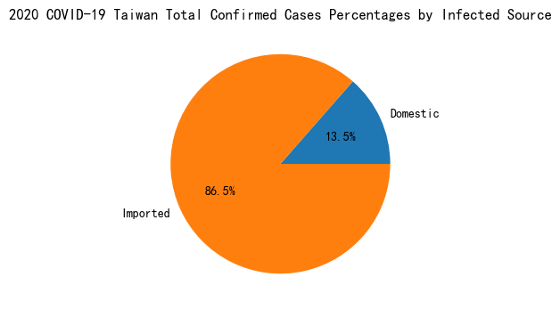

```python
fig, ax = plt.subplots(figsize=(4, 4))
plt.title('2020 COVID-19 Taiwan Total Confirmed Cases Percentages by Infected Source')
sizes = [Covid19_Taiwan_cases['Domestic'].cumsum().max(),
         Covid19_Taiwan_cases['Imported'].cumsum().max()]
plt.pie(sizes, autopct = '%.1f%%', radius = 1, labels =['Domestic', 'Imported'])
plt.show()
```

From the above pie chart of total confirmed cases by infected source, it can be concluded that most of the confirmed cases are **imported cases which is 86.5%** in total while **the domestic cases is only 13.5%**.

## 4. Relations between Variables

In this section, the relations between different variables from the dataset such as confirmed cases, deaths and recovered cases are cross-compared and analyzed.

### 4.1. The trend of Total Confirmed Cases, Deaths and Recovered in Taiwan by Date

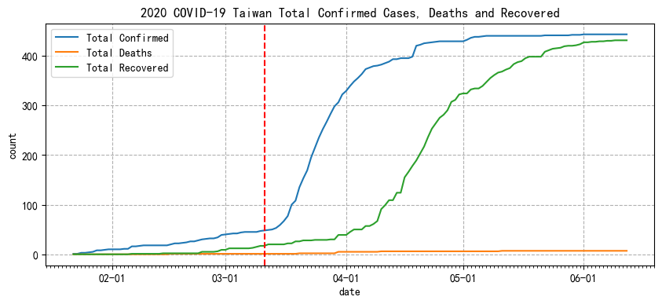

```python
Covid19_Taiwan_overall_1['ObservationDate'] = pd.to_datetime(Covid19_Taiwan_overall_1['ObservationDate'],format="%m/%d/%Y")

# 找出2020-03-11的索引
index = Covid19_Taiwan_overall_1[Covid19_Taiwan_overall_1.ObservationDate == '3/11/2020'].index.tolist()[0]
# print(index)#4790

fig, ax = plt.subplots(figsize=(10, 4))
plt.plot(Covid19_Taiwan_overall_1['ObservationDate'],Covid19_Taiwan_overall_1['Confirmed'], label = 'Total Confirmed')
plt.plot(Covid19_Taiwan_overall_1['ObservationDate'], Covid19_Taiwan_overall_1['Deaths'], label = 'Total Deaths')
plt.plot(Covid19_Taiwan_overall_1['ObservationDate'], Covid19_Taiwan_overall_1['Recovered'], label = 'Total Recovered')
plt.axvline (Covid19_Taiwan_overall_1.loc[4790,'ObservationDate'],ymin = 0, ymax = 1, color = 'red', ls = '--')
date_form = DateFormatter("%m-%d")
ax.xaxis.set_major_formatter(date_form)
ax.xaxis.set_minor_locator(mdates.DayLocator(interval = 1))
plt.legend()
plt.title('2020 COVID-19 Taiwan Total Confirmed Cases, Deaths and Recovered')
plt.grid(linestyle='--')
plt.xlabel('date')
plt.ylabel('count')
plt.show()
```

The red dash line in the above figure represents the time when WHO declared COVID-19 as a global pandemic.

### 4.2. Relations between Total Confirmed Cases, Deaths and Recovered

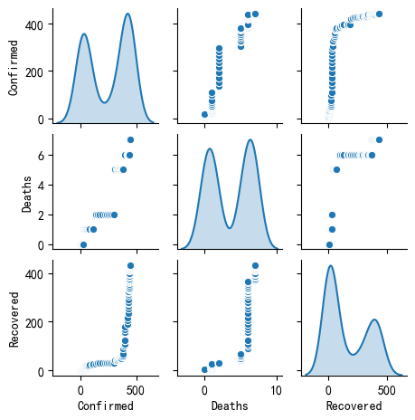

```python
Covid19_Taiwan_overall_2=Covid19_Taiwan_overall[['Confirmed','Deaths','Recovered']]
sns.pairplot(Covid19_Taiwan_overall_2, height = 1.5, diag_kind='kde')
plt.show()
```

From the above pair plot, it can be concluded that:

1. **The total of confirmed cases increases rapidly than the total deaths and recovered cases in the beginning.**
2. **The total of recovered cases is stably increasing and the increasing rate is relatively faster than the total of confirmed cases and much faster than the total of deaths now.**
3. **The growth of deaths is not continuous and the amount is relatively smaller compared with the total of confirmed cases and recovered cases.**

## 5. Conclusions

Lastly,thanks my friend **Yu-Hsiang Su** share his project data process.It is really help me doing this project very much.